# HomeWork6

Zohaib Ahmad

March 16, 2017

I. On Canvas you will ﬁnd the ﬁle crime.csv. It has two columns, one of which is the percentage of individuals in the county with at least a high-school diploma (col-umn dip), and the other is the crime rate per 100,000 residents for the counties (column rate). Consider Y to be crime rate, and X to be percentage with high school diploma. Use R to complete the following tasks:

1. Plot a scatter plot of Y and X, being sure to label the axes and give a main title.

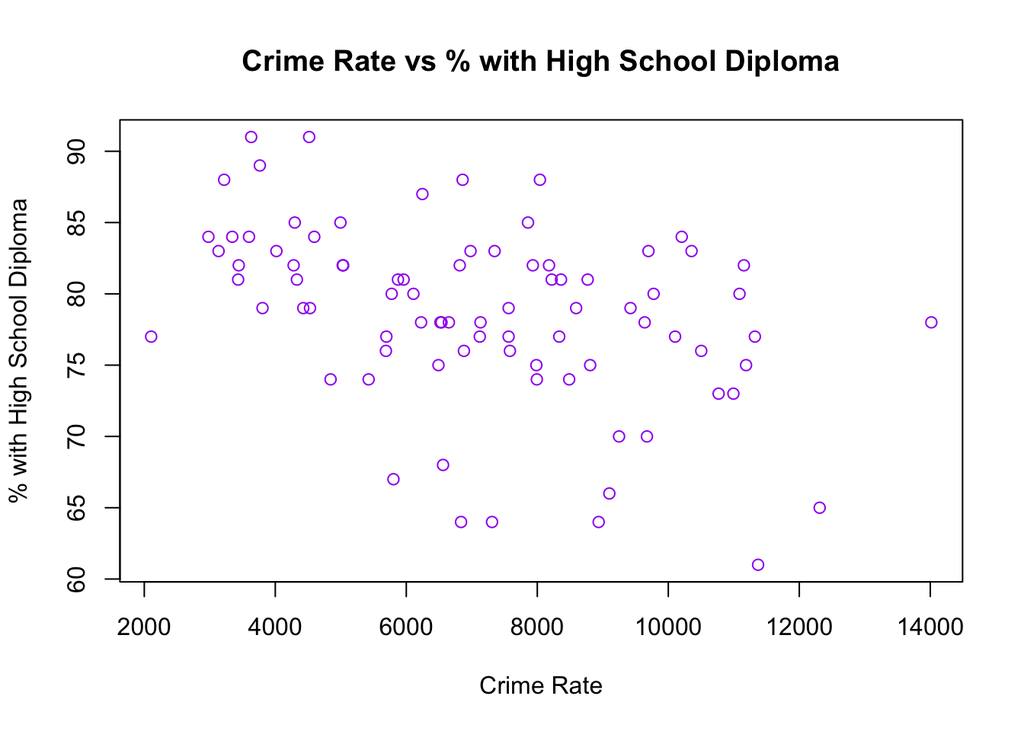

2. Calculate the estimated regression line, and plot it on the scatter plot in (a).

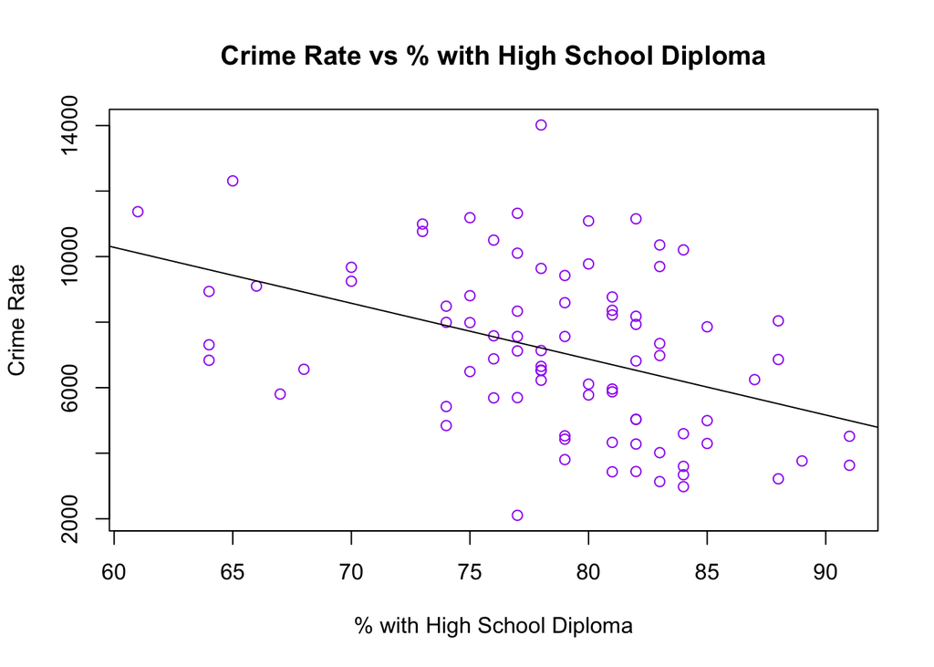

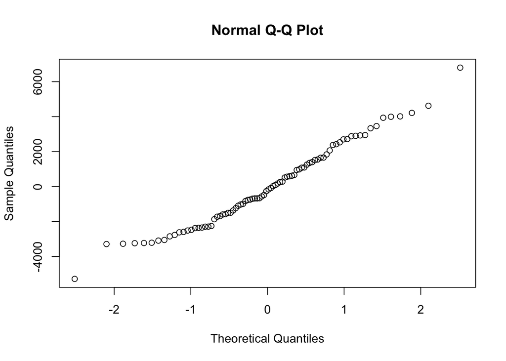

2. Create a plot of the errors vs. the ﬁtted values ( ˆ Yi’s). Does it appear the variance of the errors is constant? Explain.

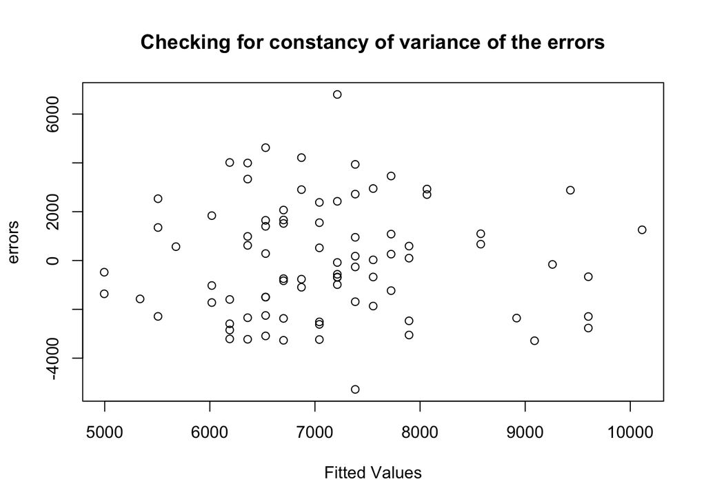

Answer: I think the variance of errors does remain very constant throughout the graph.

3. Find the 95% conﬁdence interval for the slope, and interpret it in terms of the problem.

```
##                  2.5 %      97.5 %
## (Intercept) 13997.3245 27037.87538
## X            -253.2798   -87.87061
```

4. Does the interval in (c) suggest there is a signiﬁcant linear relationship? Explain. Answer: From looking at the values for part c,there seems to be a relationship. I see that the intercept almost doubles and the X intercept almost triples.

## Code Appendix

```r
 mydata = read.csv("~/Downloads/crime.csv")
Y = mydata[,1]
X = mydata[,2]

plot(Y,X,
     xlab = "Crime Rate",
     ylab = "% with High School Diploma",
     main = "Crime Rate vs % with High School Diploma",
     col = "Purple")
this.stuff = lm(formula = Y ~ X, data = mydata)
plot(X,Y,
     xlab = "% with High School Diploma",
     ylab = "Crime Rate",
     main = "Crime Rate vs % with High School Diploma",
     col = "Purple")
abline(this.stuff,lwd=1)
qqnorm(this.stuff$residuals)
plot(this.stuff$fitted.values,this.stuff$residuals,xlab = "Fitted Values",ylab = "errors",main = "Checking for constancy of variance of the errors")
confint(this.stuff,level = 0.95)
 mydata = read.csv("~/Downloads/crime.csv")

Y = mydata[,1]
X = mydata[,2]

plot(Y,X,
     xlab = "Crime Rate",
     ylab = "% with High School Diploma",
     main = "Crime Rate vs % with High School Diploma",
     col = "Purple")

this.stuff = lm(formula = Y ~ X, data = mydata)
plot(X,Y,
     xlab = "% with High School Diploma",
     ylab = "Crime Rate",
     main = "Crime Rate vs % with High School Diploma",
     col = "Purple")
abline(this.stuff,lwd=1)

qqnorm(this.stuff$residuals)

plot(this.stuff$fitted.values,this.stuff$residuals,xlab = "Fitted Values",ylab = "errors",main = "Checking for constancy of variance of the errors")

confint(this.stuff,level = 0.95)
```